# introduction

**Introduction: elementary statistics in python**

```python
import numpy as np # linear algebra
import pandas as pd # data processing, CSV file I/O (e.g. pd.read_csv)

import os
print(os.listdir("../input")) #listing data files
```

```
['data.csv', 'test.csv', 'test2.csv', 'melb_data.csv.zip', 'melb_data.csv', 'matches.csv', 'deliveries.csv.zip', 'deliveries.csv', 'data1.csv', 'el1.csv', 'social_deltas.csv', 'AEP_hourly.csv', 'social_totals_agg.csv', 'social_totals.csv', 'airports.csv', 'airport-frequencies.csv', 'runways.csv', 'n…
```

```python
import matplotlib.pyplot as plt
print(plt.style.available) # look at available plot styles
```

```
['seaborn-ticks', 'ggplot', 'dark_background', 'bmh', 'seaborn-poster', 'seaborn-notebook', 'fast', 'seaborn', 'classic', 'Solarize_Light2', 'seaborn-dark', 'seaborn-pastel', 'seaborn-muted', '_classic_test', 'seaborn-paper', 'seaborn-colorblind', 'seaborn-bright', 'seaborn-talk', 'seaborn-dark-pale…
```

```python
#emulates the aesthetics of ggplot
plt.style.use("ggplot")
from operator import attrgetter
```

# Frequency distributions

```python
#data list indicating preference (notes) in interval [1,6]
data1 = pd.DataFrame({"preferences":[4,6,2,2,1,2,3,2,4,4]})
```

```python
fv1 = data1["preferences"].value_counts(sort=False)  #fv1 is a series
#1st column (indicating notes is the index of the series)
fv1
```

```
1    1
2    4
3    1
4    3
6    1
Name: preferences, dtype: int64
```

```python
#making data look nice: create data frame from series above
notes = pd.DataFrame({"notes":fv1.index,"frequence":fv1.values},index=range(len(fv1)))
notes
```

|  | notes | frequence |
| --- | --- | --- |
| 0 | 1 | 1 |
| 1 | 2 | 4 |
| 2 | 3 | 1 |
| 3 | 4 | 3 |
| 4 | 6 | 1 |

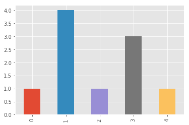

```python
plt = notes.frequence.plot.bar()
```

```python
#Let's calculate frequency distributions of another data set using intervals of data
mylist = [20,18,6,24,33,9,10,19,27,33,22,17,19,31,25,21,28,13,21,12,33,23,18,13,7,16,7,26]

#create dataframe from the list above
data2 = pd.DataFrame( {'values':mylist} )
```

```python
#defining explicit intervals of classification
fv2 = data2["values"].value_counts(sort=False,bins=[4,9,14,19,24,29,34])
print(fv2)
```

```
(3.999, 9.0]    4
(9.0, 14.0]     4
(14.0, 19.0]    6
(19.0, 24.0]    6
(24.0, 29.0]    4
(29.0, 34.0]    4
Name: values, dtype: int64
```

```python
#or calculate width
max = np.max(data2['values'])
min = np.min(data2['values'])
print("min =",min,"max =",max)
```

```
min = 6 max = 33
```

```python
fv2 = data2["values"].value_counts(sort=False,bins=range(4,35,5))
fv2
```

```
(3.999, 9.0]    4
(9.0, 14.0]     4
(14.0, 19.0]    6
(19.0, 24.0]    6
(24.0, 29.0]    4
(29.0, 34.0]    4
Name: values, dtype: int64
```

```python
#convert series result to a dataframe
table1 = pd.DataFrame({"intervals":fv2.index,"f":fv2.values},index=range(len(fv2)))
table1
```

|  | intervals | f |
| --- | --- | --- |
| 0 | (3.999, 9.0] | 4 |
| 1 | (9.0, 14.0] | 4 |
| 2 | (14.0, 19.0] | 6 |
| 3 | (19.0, 24.0] | 6 |
| 4 | (24.0, 29.0] | 4 |
| 5 | (29.0, 34.0] | 4 |

```python
#cumulative frequence
table1 = (table1.assign(F=table1.f.cumsum()))
#total number or frequencies
N = table1.f.sum()
#relative frequencies
table1['f%'] = (table1['f'] / N) * 100
table1['F%'] = (table1['F'] / N) * 100
table1
```

|  | intervals | f | F | f% | F% |
| --- | --- | --- | --- | --- | --- |
| 0 | (3.999, 9.0] | 4 | 4 | 14.285714 | 14.285714 |
| 1 | (9.0, 14.0] | 4 | 8 | 14.285714 | 28.571429 |
| 2 | (14.0, 19.0] | 6 | 14 | 21.428571 | 50.000000 |
| 3 | (19.0, 24.0] | 6 | 20 | 21.428571 | 71.428571 |
| 4 | (24.0, 29.0] | 4 | 24 | 14.285714 | 85.714286 |
| 5 | (29.0, 34.0] | 4 | 28 | 14.285714 | 100.000000 |

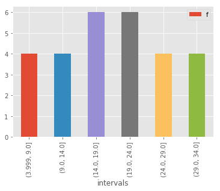

```python
plt = table1.plot.bar(x='intervals', y="f")
```

# Mean, variance and standard deviation

\begin{align} Arithmetic\,mean = {Sum\,of\,all\,numbers \over No.\,of\,values\,in\,the \,set}\,\,\,\, \end{align}

Because it's important to make distinction between population (the entire lot of elements we investigate) and the sample (a representative part of that entire lot), we have the following notations:

Sample mean: $\bar{x} = {\sum_{i=1}^{n} x_{i} \over n}$

Population mean: $\mu = {\sum_{i=1}^{n} x_{i} \over N}$

where n, N is the number of elements in data set of a sample, respective population.

In general, when we deal with population (all elements of investigation) we have *parameters* and when work with samples, we have *statistics*.

```python
mylist = [2,3,3,5,8,9,12]
#create data frame
data = pd.DataFrame( {'values':mylist} )
data
```

|  | values |
| --- | --- |
| 0 | 2 |
| 1 | 3 |
| 2 | 3 |
| 3 | 5 |
| 4 | 8 |
| 5 | 9 |
| 6 | 12 |

```python
sum_of_data = data.values.sum()
n = len(data.index)
mean = sum_of_data / n
mean
```

```
6.0
```

or

```python
mean = data.values.mean()
mean
```

```
6.0
```

```python
data['dev'] = data['values'] - mean
data
```

|  | values | dev |
| --- | --- | --- |
| 0 | 2 | -4.0 |
| 1 | 3 | -3.0 |
| 2 | 3 | -3.0 |
| 3 | 5 | -1.0 |
| 4 | 8 | 2.0 |
| 5 | 9 | 3.0 |
| 6 | 12 | 6.0 |

As we could easily verify, in every case, the sum of distances (deviations) from the mean is always 0.

$ \bar{x} = {\sum_{i=1}^{n} x_{i} \over n} \Rightarrow n \times \bar{x} = \sum_{i=1}^{n} x_{i} \quad (1) \\ \sum_{i=1}^n(x_i - \bar{x}) = x_1 - \bar{x} + x_2 - \bar{x} + ... + x_n - \bar{x} = \\ = (x_1 + x_2 + ... x_n) - n \times \bar{x} = \sum_{i=1}^{n} x_{i} - n \times \bar{x} \quad (2) \\ (1) + (2) \Rightarrow \sum_{i=1}^n(x_i - \bar{x}) = \sum_{i=1}^{n} x_{i} - \sum_{i=1}^{n} x_{i} = 0 $

So, if we try to calculate the spread of data around the mean as the sum of deviations from the mean we get 0.

```python
data.dev.sum()
```

```
0.0
```

To avoid that result, we could use the absolute values of the deviations from the mean:

Mean deviation = ${\sum_{i=1}^{n} |x_{i}-\bar{x}| \over n}$

```python
data['abs_dev'] = np.absolute(data['dev'])
data
```

|  | values | dev | abs_dev |
| --- | --- | --- | --- |
| 0 | 2 | -4.0 | 4.0 |
| 1 | 3 | -3.0 | 3.0 |
| 2 | 3 | -3.0 | 3.0 |
| 3 | 5 | -1.0 | 1.0 |
| 4 | 8 | 2.0 | 2.0 |
| 5 | 9 | 3.0 | 3.0 |
| 6 | 12 | 6.0 | 6.0 |

```python
Mean_deviation = data['abs_dev'].sum()
Mean_deviation
```

```
22.0
```

Mean deviation is a measure of spreading data around the mean but for mathematical reasons (to make easier regression analysis), instead of this mean is used the variance:

Sample variance: $S^2={\sum_{i=i}^{n} (x_{i}-\bar{x})^2 \over n-1}$ (using n-1 instead of n gives a better estimation of population variance)

n - dimension of sample

Population variance: $\sigma^2={\sum_{i=i}^{n} (x_{i}-\mu)^2 \over N}$

N - dimension of population

In order to have a measure of data spread around the mean, we have to extract radical from the mean of squared deviations.

This is standard deviation.

Standard deviation for a sample: $S = \sqrt{\sum_{i=1}^{n}{(x_i - \bar{x})}^2 \over n - 1}$

Standard deviation for population: $\sigma = \sqrt{\sum_{i=1}^{n}{(x_i - \mu)}^2 \over n}$

```python
data['square_dev'] = data['dev']**2
data
```

|  | values | dev | abs_dev | square_dev |
| --- | --- | --- | --- | --- |
| 0 | 2 | -4.0 | 4.0 | 16.0 |
| 1 | 3 | -3.0 | 3.0 | 9.0 |
| 2 | 3 | -3.0 | 3.0 | 9.0 |
| 3 | 5 | -1.0 | 1.0 | 1.0 |
| 4 | 8 | 2.0 | 2.0 | 4.0 |
| 5 | 9 | 3.0 | 3.0 | 9.0 |
| 6 | 12 | 6.0 | 6.0 | 36.0 |

```python
variance = data.square_dev.sum()/len(data.index)
print("variance=",variance)
print("std_dev=",np.sqrt(variance))
```

```
variance= 12.0
std_dev= 3.4641016151377544
```

```python
#pandas calculations
#Delta Degrees of Freedom: denominator of fraction is (n - ddof)
#in this case, biased formula with n at denominator
data['values'].std(ddof = 0)
```

```
3.4641016151377544
```

```python
#having a sample, we use unbiased formula with n-1
data['values'].std(ddof = 1)
```

```
3.7416573867739413
```

# The standard deviation of a frequency distribution

If we start from the "biased" formula (underesitmates the paramenter - std. dev. of a population investigated) of standard deviation of a sample:

$$S = \sqrt{\sum_{i=1}^{n}{(x_i - \bar{x})}^2 \over n}$$

we obtain the following equivalent formula:

$$S = \sqrt{{\sum_{i=1}^{n} x_i^2 \over n}-({\sum_{i=1}^{n} x_i \over n})^2} \quad (1)$$

Proof:

$ {\sum_{i=1}^{n} (x_i - \bar{x})^2 \over n} = \\ = {(x_1^2 - 2 x_1 \bar{x} + \bar{x}^2) + (x_2^2 - 2 x_2 \bar{x} + \bar{x}^2) + ... + (x_n^2 - 2 x_n \bar{x} + \bar{x}^2) \over n} = \\ = {x_1^2 + x_2^2 + ... + x_n^2 - 2 \bar{x} (x_1 + x_2 + ... x_n) + n \bar{x}^2 \over n} = \\ = {{{\sum_{i=1}^{n} x_i^2} - 2 { \sum_{i=1}^{n} x_i \over n} \sum_{i=1}^{n} x_i + n ({\sum_{i=1}^{n} x_i \over n})^2} \over n} = \\ = {{\sum_{i=1}^{n} x_i^2-2{(\sum_{i=1}^{n}x_i)^2\over n}+{(\sum_{i=1}^{n}x_i)^2\over n}} \over n} = \\ = {{\sum_{i=1}^{n} x_i^2 - {(\sum_{i=1}^{n} x_i)^2 \over n}} \over n} = \\ = {{\sum_{i=1}^{n} x_i^2} \over n} - ({\sum_{i=1}^{n} x_i \over n})^2 $

So, starting from the "unbiased" formula of standard deviation of a sample:

$$S = \sqrt{\sum_{i=1}^{n}{(x_i - \bar{x})}^2 \over n - 1}$$

we will have the following equivalent formula:

$$S = \sqrt{{ {n\sum_{i=1}^{n} x_i^2 - (\sum_{i=1}^{n} x_i)^2} \over n(n-1)}} \quad (2)$$

because:

$ {\sum_{i=1}^{n} (x_i - \bar{x})^2 \over n-1} = {{\sum_{i=1}^{n} x_i^2 - {(\sum_{i=1}^{n} x_i)^2 \over n}} \over n-1} = {{n\sum_{i=1}^{n} x_i^2 - (\sum_{i=1}^{n} x_i)^2} \over n(n-1)} $

In the end, the above (1) and (2), applied to a frequency distribution, will became:

$$S_{biased} = \sqrt{{\sum fm^2 \over \sum f}-({\sum fm \over \sum f})^2}$$$$S_{unbiased} = \sqrt{{ {\sum f \sum fm^2 - (\sum fm)^2} \over \sum f (\sum f-1)}}$$

where:

f - interval frequencies

m - midpoints of intervals.

Apllied to an example:

```python
# read csv (comma separated value) into dataframe
data2 = pd.read_csv('../input/test2.csv')
data2.head()
```

|  | weight |
| --- | --- |
| 0 | 130 |
| 1 | 130 |
| 2 | 120 |
| 3 | 110 |
| 4 | 89 |

```python
data_mean = data2.weight.mean()
data_sd = data2.weight.std(ddof = 1)
print("mean =",data_mean,"standard deviation =",data_sd)
```

```
mean = 119.97368421052632 standard deviation = 17.27439417657974
```

```python
data2.describe()
```

|  | weight |
| --- | --- |
| count | 38.000000 |
| mean | 119.973684 |
| std | 17.274394 |
| min | 87.000000 |
| 25% | 110.000000 |
| 50% | 120.000000 |
| 75% | 130.000000 |
| max | 170.000000 |

Now, let's classify data set into intervals of 10 units from 85 to 174

```python
#freq by intervals (interval limits analytic defined)
weight_f = data2["weight"].value_counts(sort=False,bins=[84,94,104,114,124,134,144,164,174])
weight_f
```

```
(83.999, 94.0]     3
(94.0, 104.0]      3
(104.0, 114.0]     6
(114.0, 124.0]    11
(124.0, 134.0]     9
(134.0, 144.0]     4
(144.0, 164.0]     1
(164.0, 174.0]     1
Name: weight, dtype: int64
```

```python
#interval limits defined using range
weight_f = data2["weight"].value_counts(sort=False,bins=range(84,175,10))
weight_f
```

```
(83.999, 94.0]     3
(94.0, 104.0]      3
(104.0, 114.0]     6
(114.0, 124.0]    11
(124.0, 134.0]     9
(134.0, 144.0]     4
(144.0, 154.0]     0
(154.0, 164.0]     1
(164.0, 174.0]     1
Name: weight, dtype: int64
```

```python
#convert series result to a dataframe
table = pd.DataFrame({"intervals":weight_f.index, "f":weight_f.values},index=range(len(weight_f)))
table
```

|  | intervals | f |
| --- | --- | --- |
| 0 | (83.999, 94.0] | 3 |
| 1 | (94.0, 104.0] | 3 |
| 2 | (104.0, 114.0] | 6 |
| 3 | (114.0, 124.0] | 11 |
| 4 | (124.0, 134.0] | 9 |
| 5 | (134.0, 144.0] | 4 |
| 6 | (144.0, 154.0] | 0 |
| 7 | (154.0, 164.0] | 1 |
| 8 | (164.0, 174.0] | 1 |

```python
#get middle of intervals (mean of margins)
#m stands for x values as the "representative" value for the interval
#so for the 1st row, for example, we could say we have 3 values of 88.9995
table['m'] = table['intervals'].map(attrgetter('mid'))
table
```

|  | intervals | f | m |
| --- | --- | --- | --- |
| 0 | (83.999, 94.0] | 3 | 88.9995 |
| 1 | (94.0, 104.0] | 3 | 99.0000 |
| 2 | (104.0, 114.0] | 6 | 109.0000 |
| 3 | (114.0, 124.0] | 11 | 119.0000 |
| 4 | (124.0, 134.0] | 9 | 129.0000 |
| 5 | (134.0, 144.0] | 4 | 139.0000 |
| 6 | (144.0, 154.0] | 0 | 149.0000 |
| 7 | (154.0, 164.0] | 1 | 159.0000 |
| 8 | (164.0, 174.0] | 1 | 169.0000 |

```python
table['fm'] = table['f'] * table['m']
table['fm2'] = table['f'] * table['m'] ** 2
table
```

|  | intervals | f | m | fm | fm2 |
| --- | --- | --- | --- | --- | --- |
| 0 | (83.999, 94.0] | 3 | 88.9995 | 266.9985 | 23762.733001 |
| 1 | (94.0, 104.0] | 3 | 99.0000 | 297.0000 | 29403.000000 |
| 2 | (104.0, 114.0] | 6 | 109.0000 | 654.0000 | 71286.000000 |
| 3 | (114.0, 124.0] | 11 | 119.0000 | 1309.0000 | 155771.000000 |
| 4 | (124.0, 134.0] | 9 | 129.0000 | 1161.0000 | 149769.000000 |
| 5 | (134.0, 144.0] | 4 | 139.0000 | 556.0000 | 77284.000000 |
| 6 | (144.0, 154.0] | 0 | 149.0000 | 0.0000 | 0.000000 |
| 7 | (154.0, 164.0] | 1 | 159.0000 | 159.0000 | 25281.000000 |
| 8 | (164.0, 174.0] | 1 | 169.0000 | 169.0000 | 28561.000000 |

```python
sum_f = table.f.sum()
sum_fm = table.fm.sum()
sum_fm2 = table.fm2.sum()

s = np.sqrt((sum_f * sum_fm2 - sum_fm ** 2) / (sum_f * (sum_f-1)) )
print("std. dev for freq. distribution =", s)
#which is closed to
print("std. dev of data =", data_sd)
```

```
std. dev for freq. distribution = 17.2691761602393
std. dev of data = 17.27439417657974
```

Similar, the mean of frequncy distribution is:

$$\bar{x} = {\sum fm \over \sum f}$$

```python
mean_f = sum_fm / sum_f
print("mean of freq. distrib. =",mean_f)
#which is closed to
print("data mean =", data_mean)
```

```
mean of freq. distrib. = 120.31575
data mean = 119.97368421052632
```